# Age, Density, and Late-Stage Breast Cancer

BMIN5030 Final Project

Author

Lindsey Abellard

## 0.1 Overview

My research question is: *“Does breast density change the link between age and late-stage diagnosis in cancers found within one year of screening?”* I used the [**Mammography Screening Dataset**](https://www.bcsc-research.org/index.php/datasets/mammo-screen-data) from the **Breast Cancer Surveillance Consortium (BCSC)**, which includes over 2.5 million screening mammograms from U.S. women aged 40–74, collected between 2005 and 2017.

After meeting with Dr. Anne McCarthy and Sarah Ehsan (her data analyst), I learned that some breast density and age subgroups were too small for meaningful analysis, so I simplified the model to compare two density categories (dense [c + d] vs. not dense [a + b]) and two age categories (40–49 vs. 50+). These refinements made the analysis more interpretable and statistically robust.

This project integrates public health, data science, and radiology to examine how imaging characteristics and patient demographics influence cancer detection. By combining clinical insight with quantitative analysis, the goal is to identify which groups of women may be at greater risk for late-stage diagnosis despite recent screening.

## 0.2 Introduction

Breast cancer is one of the most common cancers among women in the United States, and early detection is critical for improving treatment options and survival ([Siegel et al., 2023](https://acsjournals.onlinelibrary.wiley.com/doi/10.3322/caac.21763)). Mammography plays a key role in detecting breast cancer early, yet some women are still diagnosed at a later stage despite recent screening, including interval and missed cancers ([Niraula S., 2020](https://jamanetwork.com/journals/jamanetworkopen/fullarticle/2770959).

Breast density is one factor that may contribute to delayed detection. Dense breast tissue can mask tumors on mammography, reducing sensitivity and increasing the likelihood of later-stage diagnosis ([Boyd et al., 2007](https://www.nejm.org/doi/full/10.1056/NEJMoa062790); [Kerlikowske et al., 2015](https://www.acpjournals.org/doi/10.7326/M14-1465)). Younger women are more likely to have dense breasts and more aggressive tumor biology, suggesting that age and breast density together may influence cancer stage at diagnosis ([Zhu et al., 2023](https://www.mdpi.com/2072-6694/15/6/1917); [Checka et al., 2012](https://www.ajronline.org/doi/10.2214/AJR.10.6049)).

This project examines whether breast density modifies the relationship between age and late-stage breast cancer among cancers diagnosed within one year of screening, with the goal of identifying subgroups at higher risk for delayed detection despite routine mammography.

### 0.2.1 **Data and Variables**

**Primary predictors**

- **age_group2** – Age group at screening (40–49 vs. 50+).
- **density_binary** – Breast density (dense vs. not dense).

**Covariates / Adjustment variables**

- **examyear_cat** – Exam year category.
- **riskBCSC_v2_5y_cat** – BCSC 5-year breast cancer risk category.
- **resinit_c** – Initial screening result (positive vs. negative).
- **resfnl_c** – Final BI-RADS 4–5 assessment.

**resfnl_c3** – Final BI-RADS 3–5 assessment.

**Outcome**

- **stage_advanced** – Advanced-stage breast cancer at diagnosis.

**Cohort Definition Variables (not used as predictors)** Used only to restrict the dataset to cancers diagnosed within 1 year of screening:

- **cancscrfu1yr_c** – Any breast cancer within 1 year (required to be 1).
- **invscrfu1yr_c** – Used to confirm invasive cancers.
- **dcisscrfu1yr_c** – Used to confirm DCIS cases.

## 0.3 Methods

To evaluate whether breast density modifies the relationship between age and late-stage diagnosis, I used a **logistic regression** and **random forest** model to compare linear and nonlinear approaches. The dataset was divided into training and testing subsets using a stratified split to maintain the proportion of early- and late-stage cases. Model performance was tested using 10-fold cross-validation.

Because late-stage diagnoses were relatively rare, I used downsampling to address class imbalance where the majority class (early-stage) class was reduced during training to balance the dataset.

The performance metrics area under the ROC curve (AUC) and sensitivity were compared across models and imbalance-handling strategies.

```r
library(tidyverse)
mammography <- read_csv("/Users/linabel/Desktop/dsst389/data/bcsc_mammo_performance.csv")
```

# 1 Cohort Definition & Variable Recoding

```r
library(dplyr)
library(stringr)
library(tidyr)   # for drop_na
library(gt)

# str_extract extracts the first character (0 or 1) and keeps only the numeric code
# In the dataset each row represented multiple mammograms so uncount() expands the dataset so each mammogram becomes one row based on the count column
mammography <- mammography |>
  mutate(
    resinit_c        = str_extract(resinit_c, "^[01]"),
    resfnl_c         = str_extract(resfnl_c, "^[01]"),
    resfnl_c3        = str_extract(resfnl_c3, "^[01]"),
    cancscrfu1yr_c   = str_extract(cancscrfu1yr_c, "^[01]"),
    dcisscrfu1yr_c   = str_extract(dcisscrfu1yr_c, "^[01]"),
    invscrfu1yr_c    = str_extract(invscrfu1yr_c, "^[01]"),
    stage_advanced   = str_extract(stage_advanced, "^[01]")
  ) |>
  uncount(weights = count)

# Create new binary predictors (age_group2, density_binary,stage_advanced) and reorder columns
mmg <- mammography %>%
  mutate(
    age_group2 = ifelse(grepl("40", agegrp), "young", "older"),
    density_binary = case_when(
      density_c %in% c("a","b") ~ "not_dense",
      density_c %in% c("c","d") ~ "dense",
      TRUE ~ NA_character_
    ),
    stage_advanced = factor(stage_advanced, levels = c("0","1"),
                            labels = c("early","late"))
  ) %>%
  dplyr::select(stage_advanced, age_group2, density_binary, dplyr::everything())

# Clean up text variables and fix unknown categories
mmg <- mmg %>%
  mutate(
    density_c = tolower(trimws(density_c)),
    riskBCSC_v2_5y_cat = tolower(trimws(riskBCSC_v2_5y_cat))
  ) %>%
  mutate(
    density_c = na_if(density_c, "unknown"),
    riskBCSC_v2_5y_cat = na_if(riskBCSC_v2_5y_cat, "unknown"),
    density_c = ifelse(density_c %in% c("", "na", "n/a"), NA, density_c),
    riskBCSC_v2_5y_cat = ifelse(riskBCSC_v2_5y_cat %in% c("", "na", "n/a"), NA, riskBCSC_v2_5y_cat)
  )

# remove rows missing in modeling variables and filter data to only include cancers diagnosed within 1 year
mmg_clean <- mmg %>%
  tidyr::drop_na(stage_advanced, age_group2, density_binary) %>%
  filter(cancscrfu1yr_c == 1)

# Summarize outcome distribution
mmg_clean %>%
 count(stage_advanced) %>%
  mutate(prop = n/sum(n)) %>%
  gt() %>%
  tab_header(title = "Stage distribution among cancers within 1 year")
```

Stage distribution among cancers within 1 year

| stage_advanced | n | prop |
| --- | --- | --- |
| early | 9958 | 0.90667395 |
| late | 1025 | 0.09332605 |

Among women diagnosed with breast cancer within one year of screening, 9% (n = 1,025) presented with a late-stage (advanced) diagnosis, while the majority, about 91% (n = 9,958) — were diagnosed at an early stage.

This distribution suggests that most cancers detected within one year of screening are found at earlier stages. The smaller proportion of late-stage diagnoses may reflect differences in tumor biology, screening sensitivity, or individual-level factors like age and breast density, which will be examined in later analyses.

# 2 Results

```r
library(tidyverse)
library(tidymodels)
library(naniar)
library(vip)
library(ggplot2)
library(gt)
library(themis)
library(ranger)
theme_set(theme_minimal())
set.seed(2025)
```

# 3 Exploratory Analysis

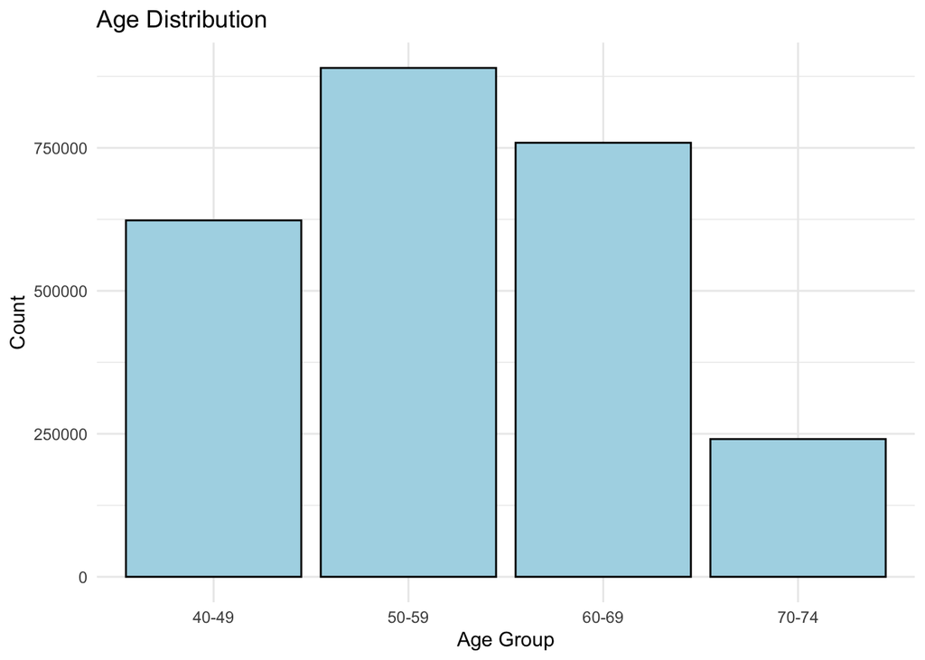

```r
library(ggplot2)

mammography |>
  ggplot(aes(x = agegrp)) +
  geom_bar(fill = "lightblue", color = "black") +
  labs(
    title = "Age Distribution",
    x = "Age Group",
    y = "Count"
  ) +
  theme_minimal()
```

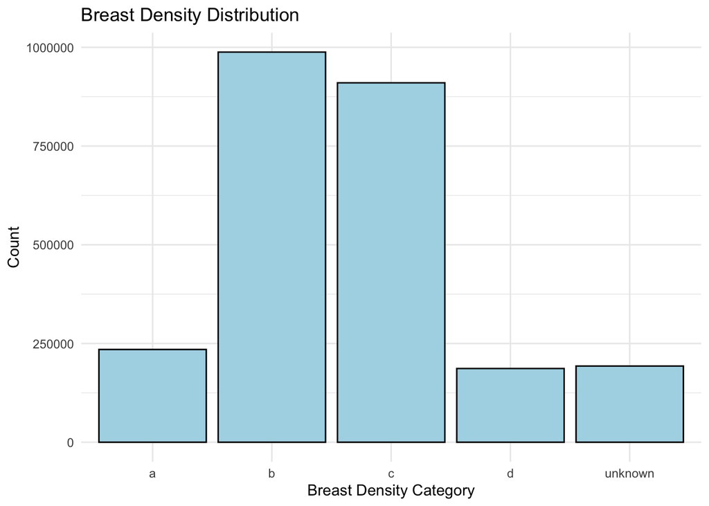

```r
mammography |>
  ggplot(aes(x = density_c)) +
  geom_bar(fill = "lightblue", color = "black") +
  labs(
    title = "Breast Density Distribution",
    x = "Breast Density Category",
    y = "Count"
  ) +
  theme_minimal()
```

The most common breast density types are scattered fibroglandular densities (b) and heterogeneously dense (c), while almost entirely fatty (a) and extremely dense (d) breasts are less frequent. This distribution suggests that most individuals in the dataset have moderate breast density, which is consistent with typical screening populations.

```
Ignoring unknown labels:
• fill : "Advanced Stage"
```

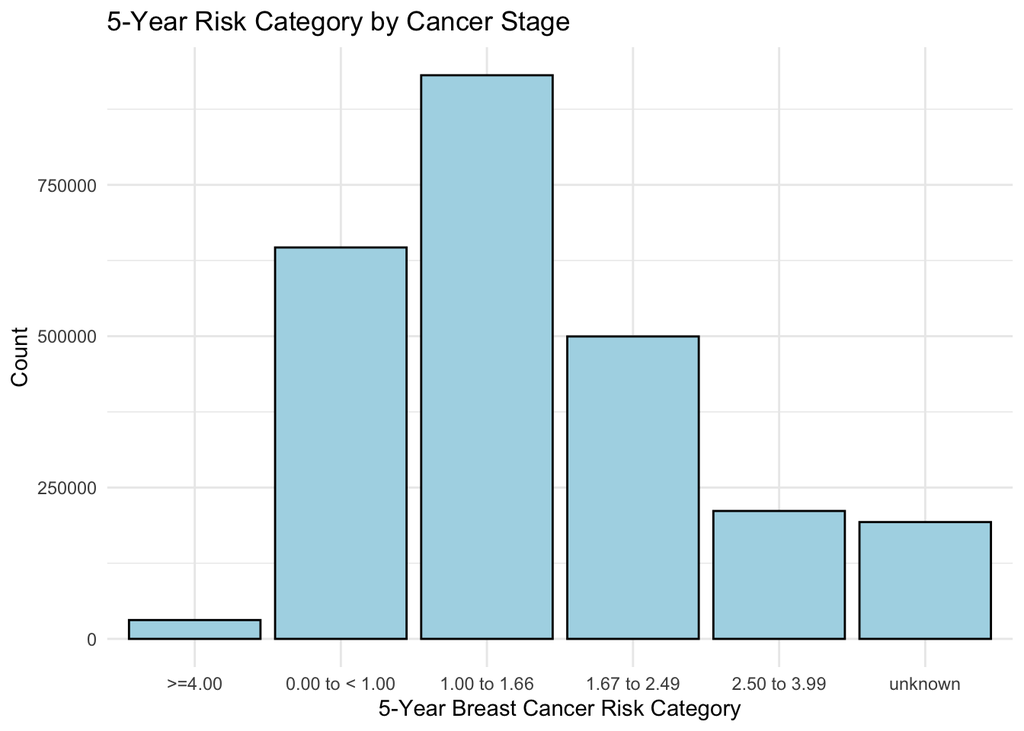

```r
mammography |>
  ggplot(aes(x = riskBCSC_v2_5y_cat)) +
  geom_bar(fill = "lightblue", color = "black") +
  labs(
    title = "5-Year Risk Category by Cancer Stage",
    x = "5-Year Breast Cancer Risk Category",
    y = "Count",
    fill = "Advanced Stage"
  ) +
  theme_minimal()
```

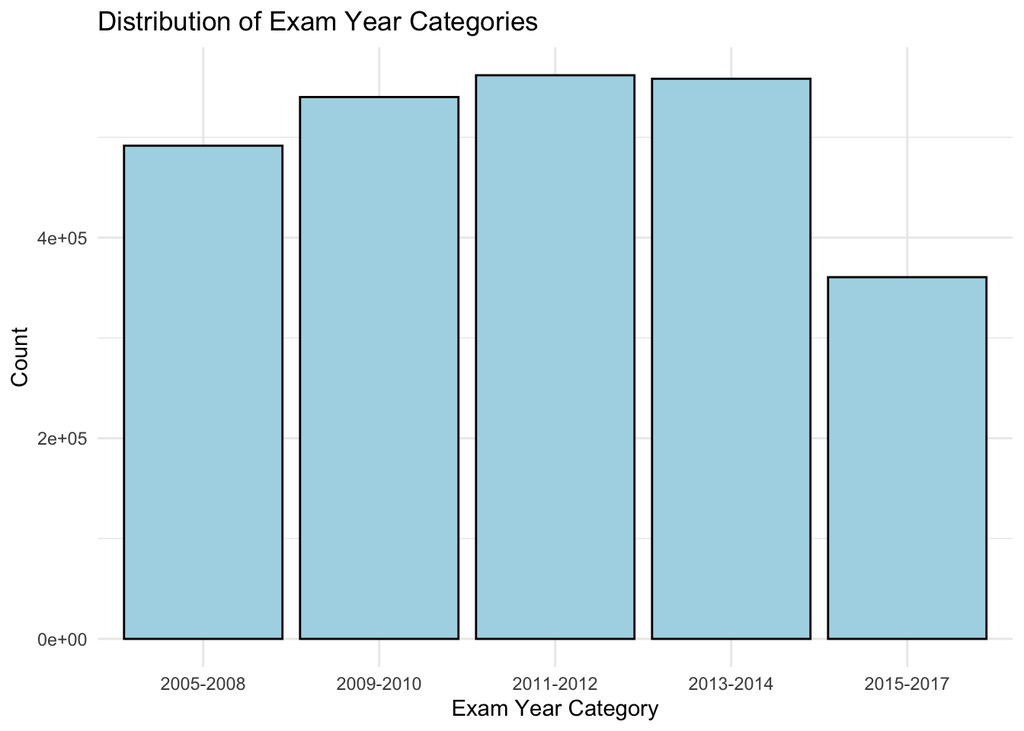

```r
mammography |>
  ggplot(aes(x = examyear_cat)) +
  geom_bar(fill = "lightblue", color = "black") +
  labs(
    title = "Distribution of Exam Year Categories",
    x = "Exam Year Category",
    y = "Count"
  ) +
  theme_minimal()
```

```r
mammography |>
  count(stage_advanced) |>
  mutate(proportion = n / sum(n))
```

```
# A tibble: 2 × 3
  stage_advanced       n proportion
  <chr>            <int>      <dbl>
1 0              2511442   1.000
2 1                 1135   0.000452
```

The classes are highly imbalanced. A model that already predicts “early stage” would already get overall high accuracy, even while missing most advanced cases. Down sampling might be needed to help the model better identify minority (advance-stage) cases.

```r
mammography%>%
  filter(invscrfu1yr_c == 1) %>%
  count(agegrp, density_c, stage_advanced) %>%
  group_by(agegrp, density_c) %>%
  mutate(prop = n / sum(n))
```

```
# A tibble: 40 × 5
# Groups:   agegrp, density_c [20]
   agegrp density_c stage_advanced     n  prop
   <chr>  <chr>     <chr>          <int> <dbl>
 1 40-49  a         0                 15 0.833
 2 40-49  a         1                  3 0.167
 3 40-49  b         0                273 0.869
 4 40-49  b         1                 41 0.131
 5 40-49  c         0                560 0.814
 6 40-49  c         1                128 0.186
 7 40-49  d         0                183 0.762
 8 40-49  d         1                 57 0.238
 9 40-49  unknown   0                118 0.868
10 40-49  unknown   1                 18 0.132
# ℹ 30 more rows
```

Many age–density combinations had very small numbers of late-stage cancers, making estimates unstable within those groups. Based on this sparsity, my advisor recommended collapsing categories. I grouped age into two categories (40–49 vs. 50+) and breast density into dense vs. not dense, so that each subgroup would have larger, more reliable sample sizes.

## 3.1 Missingness Summary

```r
library(naniar)
library(dplyr)
library(gt)

# convert dataset into a plain tibble
mmg_tbl <- dplyr::as_tibble(mmg)

# make summary table of missing values for each variables
miss_tbl <- naniar::miss_var_summary(mmg_tbl) %>%
  dplyr::arrange(dplyr::desc(pct_miss))

# Display the top 20 variables with the most missingness
miss_tbl %>%
  dplyr::slice(1:min(20, n())) %>%
  gt::gt() %>%
  gt::tab_header(title = "Top variables by missingness")
```

Top variables by missingness

| variable | n_miss | pct_miss |
| --- | --- | --- |
| density_binary | 192934 | 7.68 |
| density_c | 192934 | 7.68 |
| riskBCSC_v2_5y_cat | 192934 | 7.68 |
| stage_advanced | 0 | 0 |
| age_group2 | 0 | 0 |
| agegrp | 0 | 0 |
| examyear_cat | 0 | 0 |
| resinit_c | 0 | 0 |
| resfnl_c | 0 | 0 |
| resfnl_c3 | 0 | 0 |
| cancscrfu1yr_c | 0 | 0 |
| dcisscrfu1yr_c | 0 | 0 |
| invscrfu1yr_c | 0 | 0 |

Missingness in breast density (density_c), BCSC 5-year risk estimates (riskBCSC_v2_5y_cat), happened in the same 7.7% of mammograms, reflecting exams without enough data for risk estimation or density classification. The derived variable density_binary shared this same missing pattern.

```r
mmg %>%
  group_by(agegrp) %>%
  summarise(
    n = n(),
    n_missing_density = sum(is.na(density_c)),
    prop_missing_density = n_missing_density / n
  ) %>%
  gt() %>%
  tab_header(title = "Missing breast density by age group")
```

Missing breast density by age group

| agegrp | n | n_missing_density | prop_missing_density |
| --- | --- | --- | --- |
| 40-49 | 623156 | 53829 | 0.08638126 |
| 50-59 | 889719 | 70438 | 0.07916882 |
| 60-69 | 758883 | 53744 | 0.07081988 |
| 70-74 | 240819 | 14923 | 0.06196770 |

Missingness in breast density was relatively low across all age groups, ranging from 6.2% to 8.6%. The proportion of missing density values was slightly higher among younger women aged 40–49 (8.6%), compared with 50–59 (7.9%), 60–69 (7.1%), and 70–74 (6.2%). This suggests that missing density information is modest and does not appear to differ significantly by age group.

# 4 Descriptive Analysis

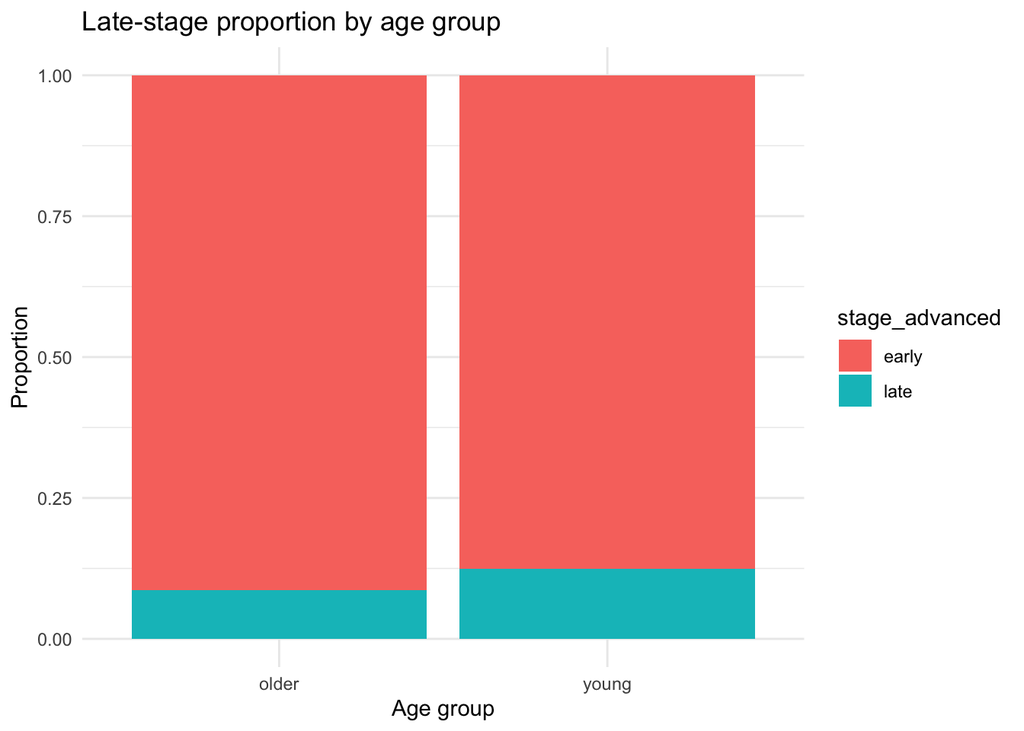

```r
mmg_clean %>%
  ggplot(aes(x = age_group2, fill = stage_advanced)) +
  geom_bar(position = "fill") +
  labs(y = "Proportion", x = "Age group", title = "Late-stage proportion by age group")
```

There is a slightly higher proportion of young (40-49) individuals who are diagnosed with late stage diagnosis within one year compared to older individuals.

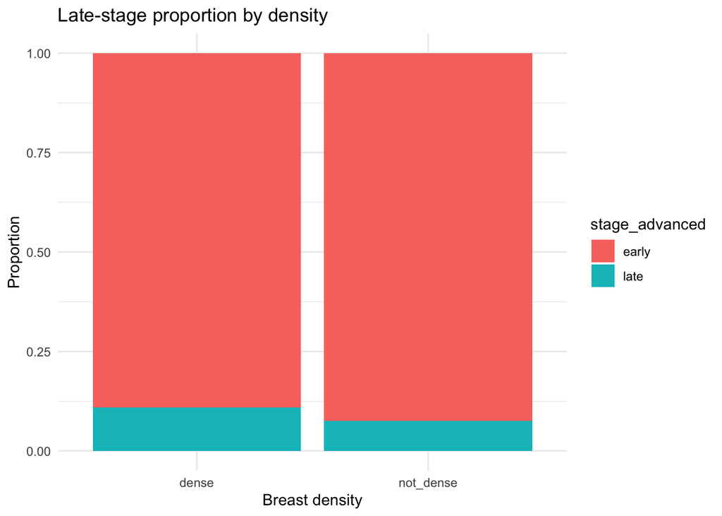

```r
mmg_clean %>%
  ggplot(aes(x = density_binary, fill = stage_advanced)) +
  geom_bar(position = "fill") +
  labs(y = "Proportion", x = "Breast density", title = "Late-stage proportion by density")
```

There is a slightly higher proportion of individuals with dense breasts that are diagnosed with late stage breast cancer compared to individuals with not dense breasts.

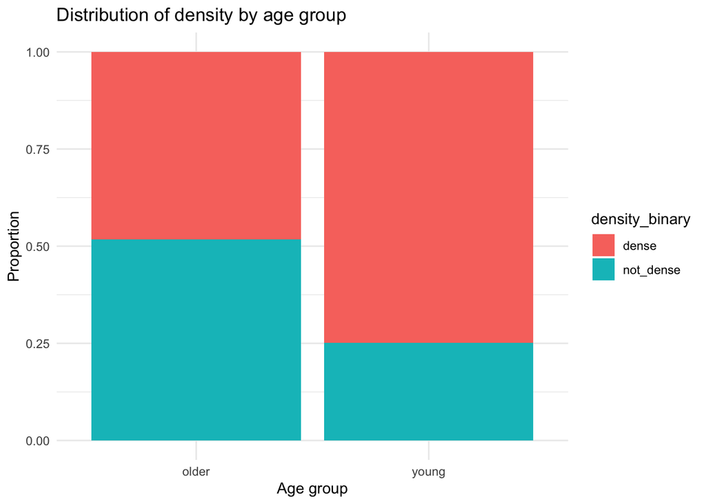

```r
mmg_clean %>%
  ggplot(aes(x = age_group2, fill = density_binary)) +
  geom_bar(position = "fill") +
  labs(y = "Proportion", x = "Age group", title = "Distribution of density by age group")
```

Younger women had a higher proportion of dense breasts compared to older women, while older women showed a more balanced distribution of dense and non-dense breast tissue.

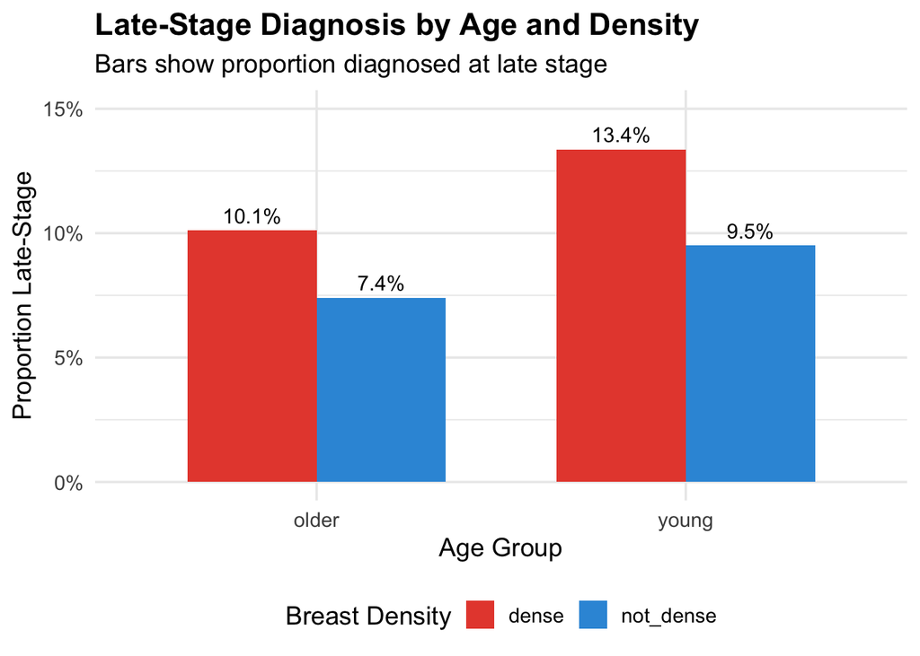

```r
# Create 2x2 stratified proportions
strat_data <- mmg_clean %>%
  group_by(age_group2, density_binary) %>%
  summarise(
    total = n(),
    late = sum(stage_advanced == "late"),
    prop_late = late / total,
    .groups = "drop"
  )

ggplot(strat_data, aes(x = age_group2, y = prop_late, fill = density_binary)) +
  geom_col(position = "dodge", width = 0.7) +
  geom_text(aes(label = paste0(round(prop_late * 100, 1), "%")),
            position = position_dodge(width = 0.7),
            vjust = -0.5, size = 4) +
  scale_y_continuous(labels = scales::percent_format(),
                     limits = c(0, 0.15)) +
  scale_fill_manual(values = c("dense" = "#E74C3C", "not_dense" = "#3498DB")) +
  labs(
    title = "Late-Stage Diagnosis by Age and Density",
    subtitle = "Bars show proportion diagnosed at late stage",
    x = "Age Group",
    y = "Proportion Late-Stage",
    fill = "Breast Density"
  ) +
  theme_minimal(base_size = 14) +
  theme(
    plot.title = element_text(face = "bold"),
    legend.position = "bottom"
  )
```

The proportion of late-stage diagnoses is higher among women with dense breasts than non-dense breasts in both age groups, with younger women showing higher proportions overall. The highest late-stage proportion is observed among younger women with dense breasts.

```r
library(dplyr)
library(tidyr)
library(gt)


stage_tab <- mmg_clean %>%
  count(stage_advanced) %>%
  mutate(
    pct   = round(100 * n / sum(n), 1),
    N_pct = paste0(n, " (", pct, "%)")
  ) %>%
  tidyr::pivot_wider(
    names_from  = stage_advanced,
    values_from = N_pct
  ) %>%
  mutate(
    Variable = "Stage at diagnosis",
    Category = "All cancers",
    .before  = 1
  ) %>%
  dplyr::select(Variable, Category, early, late)

## make one table per variable, stratified by stage
make_tab <- function(data, var, var_label) {
  tab <- data %>%
    count(stage_advanced, {{ var }}) %>%
    group_by(stage_advanced) %>%
    mutate(
      pct   = round(100 * n / sum(n), 1),
      N_pct = paste0(n, " (", pct, "%)")
    ) %>%
    ungroup() %>%
    tidyr::pivot_wider(
      id_cols    = {{ var }},
      names_from = stage_advanced,
      values_from = N_pct,
      values_fill = "0 (0.0%)"
    )

  tab$Variable <- var_label
  tab <- tab[, c("Variable", deparse(substitute(var)), "early", "late")]
  names(tab)[2] <- "Category"
  tab
}

##  tables for each variable
age_tab    <- make_tab(mmg_clean, age_group2,         "Age group")
dens_tab   <- make_tab(mmg_clean, density_binary,     "Breast density")
init_tab   <- make_tab(mmg_clean, resinit_c,          "Initial BI-RADS")
final3_tab <- make_tab(mmg_clean, resfnl_c3,          "Final BI-RADS 3–5")
risk_tab   <- make_tab(mmg_clean, riskBCSC_v2_5y_cat, "BCSC 5-year risk")
year_tab   <- make_tab(mmg_clean, examyear_cat,       "Exam year category")

##  Combine
desc_by_stage <- bind_rows(
  stage_tab,
  age_tab,
  dens_tab,
  init_tab,
  final3_tab,
  risk_tab,
  year_tab
)

## get p-value (chi-square, fallback to Fisher)
get_pval <- function(data, var) {
  v   <- data[[deparse(substitute(var))]]
  tbl <- table(v, data$stage_advanced)
  ct  <- suppressWarnings(chisq.test(tbl))
  if (any(ct$expected < 5)) {
    test <- fisher.test(tbl)
  } else {
    test <- ct
  }
  test$p.value
}

##  P-values for each variable vs stage (early vs late)
pvals <- tibble(
  Variable = c(
    "Age group",
    "Breast density",
    "Initial BI-RADS",
    "Final BI-RADS 3–5",
    "BCSC 5-year risk",
    "Exam year category"
  ),
  p_value = c(
    get_pval(mmg_clean, age_group2),
    get_pval(mmg_clean, density_binary),
    get_pval(mmg_clean, resinit_c),
    get_pval(mmg_clean, resfnl_c3),
    get_pval(mmg_clean, riskBCSC_v2_5y_cat),
    get_pval(mmg_clean, examyear_cat)
  )
)


desc_by_stage <- desc_by_stage %>%
  left_join(pvals, by = "Variable") %>%
  group_by(Variable) %>%
  mutate(
    p_value_fmt = ifelse(
      row_number() == 1 & !is.na(p_value),
      format.pval(p_value, digits = 3, eps = 0.001),
      ""
    )
  ) %>%
  ungroup() %>%
  dplyr::select(Variable, Category, early, late, p_value_fmt)


desc_by_stage %>%
  gt() %>%
  tab_header(
    title    = md("**Table 1. Characteristics of Breast Cancers by Stage**"),
    subtitle = "Cancers diagnosed within 1 year of screening"
  ) %>%
  cols_label(
    Variable    = "Variable",
    Category    = "Category",
    early       = "Early Stage",
    late        = "Late Stage",
    p_value_fmt = "P-value"
  ) %>%
  cols_align(
    align   = "left",
    columns = c(Variable, Category)
  ) %>%
  cols_align(
    align   = "center",
    columns = c(early, late, p_value_fmt)
  ) %>%
  tab_row_group(
    label = "Overall",
    rows  = Variable == "Stage at diagnosis"
  ) %>%
  tab_row_group(
    label = "Demographics",
    rows  = Variable %in% c("Age group")
  ) %>%
  tab_row_group(
    label = "Clinical Factors",
    rows  = Variable %in% c("Breast density", "BCSC 5-year risk")
  ) %>%
  tab_row_group(
    label = "Screening Results",
    rows  = Variable %in% c("Initial BI-RADS", "Final BI-RADS 3–5")
  ) %>%
  tab_row_group(
    label = "Study Period",
    rows  = Variable %in% c("Exam year category")
  ) %>%
  tab_style(
    style = cell_fill(color = "#F0F0F0"),
    locations = cells_body(
      columns = everything(),
      rows    = Variable != dplyr::lag(Variable, default = "")
    )
  ) %>%
  tab_style(
    style = cell_text(weight = "bold"),
    locations = cells_body(columns = Variable)
  ) %>%
  tab_style(
    style = cell_text(weight = "bold"),
    locations = cells_column_labels(everything())
  ) %>%
  tab_options(
    table.font.size             = 12,
    heading.title.font.size     = 16,
    heading.subtitle.font.size  = 13,
    heading.align               = "left",
    column_labels.font.weight   = "bold",
    row_group.font.weight       = "bold",
    table.border.top.style      = "solid",
    table.border.bottom.style   = "solid",
    column_labels.border.bottom.style = "solid",
    column_labels.border.bottom.width = 2,
    table_body.hlines.style     = "none",
    table.width                 = pct(100)
  ) %>%
  tab_source_note(
    source_note = md("*N* = 10,983 breast cancer cases diagnosed within 1 year of screening mammography")
  )
```

**Table 1. Characteristics of Breast Cancers by Stage**

Cancers diagnosed within 1 year of screening

| Variable | Category | Early Stage | Late Stage | P-value |
| --- | --- | --- | --- | --- |
| Study Period |  |  |  |  |
| Exam year category | 2005-2008 | 1591 (16%) | 162 (15.8%) | 0.259 |
| Exam year category | 2009-2010 | 2056 (20.6%) | 209 (20.4%) |  |
| Exam year category | 2011-2012 | 2213 (22.2%) | 228 (22.2%) |  |
| Exam year category | 2013-2014 | 2436 (24.5%) | 229 (22.3%) |  |
| Exam year category | 2015-2017 | 1662 (16.7%) | 197 (19.2%) |  |
| Screening Results |  |  |  |  |
| Initial BI-RADS | 0 | 1218 (12.2%) | 380 (37.1%) | <0.001 |
| Initial BI-RADS | 1 | 8740 (87.8%) | 645 (62.9%) |  |
| Final BI-RADS 3–5 | 0 | 1355 (13.6%) | 421 (41.1%) | <0.001 |
| Final BI-RADS 3–5 | 1 | 8603 (86.4%) | 604 (58.9%) |  |
| Clinical Factors |  |  |  |  |
| Breast density | dense | 5165 (51.9%) | 631 (61.6%) | <0.001 |
| Breast density | not_dense | 4793 (48.1%) | 394 (38.4%) |  |
| BCSC 5-year risk | 0.00 to < 1.00 | 1482 (14.9%) | 174 (17%) | 0.0606 |
| BCSC 5-year risk | 1.00 to 1.66 | 3734 (37.5%) | 352 (34.3%) |  |
| BCSC 5-year risk | 1.67 to 2.49 | 2776 (27.9%) | 289 (28.2%) |  |
| BCSC 5-year risk | 2.50 to 3.99 | 1627 (16.3%) | 163 (15.9%) |  |
| BCSC 5-year risk | >=4.00 | 339 (3.4%) | 47 (4.6%) |  |
| Demographics |  |  |  |  |
| Age group | older | 8340 (83.8%) | 796 (77.7%) | <0.001 |
| Age group | young | 1618 (16.2%) | 229 (22.3%) |  |
| Overall |  |  |  |  |
| Stage at diagnosis | All cancers | 9958 (90.7%) | NA |  |
| Stage at diagnosis | All cancers | NA | 1025 (9.3%) |  |

*N* = 10,983 breast cancer cases diagnosed within 1 year of screening mammography

## 4.1 Train/Test Split (Stratified)

```r
# The data is split into 80% training and 20% testing, stratified on stage_advanced so the imbalance between early and late is preserved in both sets
set.seed(123)
split <- initial_split(mmg_clean, prop = 0.8, strata = stage_advanced)
train <- training(split)
test  <- testing(split)

train %>% count(stage_advanced) %>% mutate(prop = n/sum(n)) %>% gt() %>%
  tab_header(title = "Train set outcome distribution")
```

Train set outcome distribution

| stage_advanced | n | prop |
| --- | --- | --- |
| early | 7978 | 0.90803551 |
| late | 808 | 0.09196449 |

## 4.2 Recipe

```r
# The model formula is defined using predictors of interest
base_recipe <- recipe(
  stage_advanced ~ age_group2 + density_binary +
    examyear_cat + riskBCSC_v2_5y_cat +
    resinit_c + resfnl_c + resfnl_c3,
  data = train ) %>%
  step_interact(~ age_group2:density_binary) %>% # an interaction term between age group and density is added
  step_dummy(all_nominal_predictors(), one_hot = TRUE) %>% # converts categorical predictors to dummy variables
  step_zv(all_predictors()) # removes predictors with zero variance
```

## 4.3 Models

```r
# Logistic regression

# Penalty controls how strongly the model shrinks coefficients, 0.1 is small enough to reduce overfitting without making the model so weak that it erases real association.
# Pure ridge regression (mixture = 0) is used because it shrinks coefficients but doesn't remove variables (need to retain full model). Multicolinearity (ex. age & year of exam/ breast density) is handled by spreading penalty across correlated variables
lr_spec <- logistic_reg(penalty = 0.1, mixture = 0) %>%
  set_engine("glmnet") %>%
  set_mode("classification")

# Random forest

# 500 trees is enough to stabilize the trees, adding more would not improve performance significantly
# the minimum observations in a leaf is 10 because if leaves get too small (<5), the model memorizes noise leading to overfitting, this will improve generalization
rf_spec <- rand_forest(trees = 500, min_n = 10) %>%
  set_engine("randomForest", importance = TRUE) %>%
  set_mode("classification")
```

The logistic regression model will try hard to explain the few late stage cases and may overreact to small quirks, leading to unstable coefficient estimates. Regularization well help to tame this.

## 4.4 Workflows

```r
# bundling together the model and recipe to ensure the same pre-processing
lr_wf <- workflow() %>% add_model(lr_spec) %>% add_recipe(base_recipe)
rf_wf <- workflow() %>% add_model(rf_spec) %>% add_recipe(base_recipe)
```

## 4.5 10-fold Cross-Validation (Stratified)

```r
set.seed(123)

# splitting the data into 10 folds (9 folds train the data and 1 fold evaluates it), each fold maintains same proportion of advanced stage cancer
folds <- vfold_cv(train, v = 10, strata = stage_advanced)

# save predictions from each fold
ctrl <- control_resamples(save_pred = TRUE)

# fits the workflow (recipe + model) inside each fold and calculates performance metrics
lr_cv <- fit_resamples(lr_wf, folds, control = ctrl)
```

[output not shown]

[output not shown]

[output not shown]

```r
rf_cv <- fit_resamples(rf_wf, folds, control = ctrl)
```

[output not shown]

[output not shown]

[output not shown]

[output not shown]

[output not shown]

[output not shown]

[output not shown]

[output not shown]

[output not shown]

[output not shown]

```r
# returns the average of the 10 held-out performance scores to see how well the model does on unseen data
collect_metrics(lr_cv) %>% filter(.metric %in% c("roc_auc","accuracy")) %>% gt()
```

| .metric | .estimator | mean | n | std_err | .config |
| --- | --- | --- | --- | --- | --- |
| accuracy | binary | 0.9080332 | 10 | 0.002921687 | pre0_mod0_post0 |
| roc_auc | binary | 0.6555844 | 10 | 0.007079759 | pre0_mod0_post0 |

```r
collect_metrics(rf_cv) %>% filter(.metric %in% c("roc_auc","accuracy")) %>% gt()
```

| .metric | .estimator | mean | n | std_err | .config |
| --- | --- | --- | --- | --- | --- |
| accuracy | binary | 0.9080332 | 10 | 0.002921687 | pre0_mod0_post0 |
| roc_auc | binary | 0.5640363 | 10 | 0.011200952 | pre0_mod0_post0 |

## 4.6 Model Cross-Validation Performance

During 10-fold cross-validation, the logistic regression model produced an average accuracy of 0.91 and AUC of 0.66, while the random forest model reached a similar accuracy (0.91) but a lower AUC (0.56). The accuracy is high because most observations belong to the early-stage (majority) class, meaning the models correctly classify many of these but miss many late-stage cases. The AUC assessed how well the model separates early vs. late stage. The logistic regression shows moderate discrimination (AUC ≈ 0.65), while the random forest performs only slightly better than random (AUC ≈ 0.56).Both models fit the dominant class well, but logistic regression generalizes better for identifying late-stage cancers. This suggests that downsampling should be used to improve discrimination.

The Random Forest performs worse because the predictors are mostly low-dimensional categorical variables, which provide too few informative splits for a tree-based model to leverage, while Logistic Regression handles these relationships more efficiently.

## 4.7 Fit on Training & Evaluate on Test (Unweighted Models)

```r
# Fit models on the training set
lr_fit <- fit(lr_wf, train)
rf_fit <- fit(rf_wf, train)
# Get predicted probabilities on the held-out test sets
lr_test_probs <- predict(lr_fit, test, type = "prob") %>% bind_cols(truth = test$stage_advanced)
rf_test_probs <- predict(rf_fit, test, type = "prob") %>% bind_cols(truth = test$stage_advanced)

# Compute AUC on the test set for each model
lr_auc_test <- roc_auc(lr_test_probs, truth, .pred_late, event_level = "second")
rf_auc_test <- roc_auc(rf_test_probs, truth, .pred_late, event_level = "second")

# Create a small summary table of test AUCs
bind_rows(
  tibble(Model = "LR (Test)", AUC = lr_auc_test$.estimate),
  tibble(Model = "RF (Test)", AUC = rf_auc_test$.estimate)
) %>% gt() %>% tab_header(title = "Test set AUCs")
```

Test set AUCs

| Model | AUC |
| --- | --- |
| LR (Test) | 0.6530384 |
| RF (Test) | 0.5646430 |

When evaluated on the held-out test set, logistic regression achieved an AUC of 0.65, while the random forest reached 0.57. This mirrors the cross-validation results: both models perform only modestly better than random, with logistic regression generalizing better than random forest. Given the strong class imbalance and lack of tuned weighting/sampling, these modest AUCs may reflect either a weak true association between predictors and stage or incomplete capture of the relationship.

## 4.8 ROC Curves (Test Set)

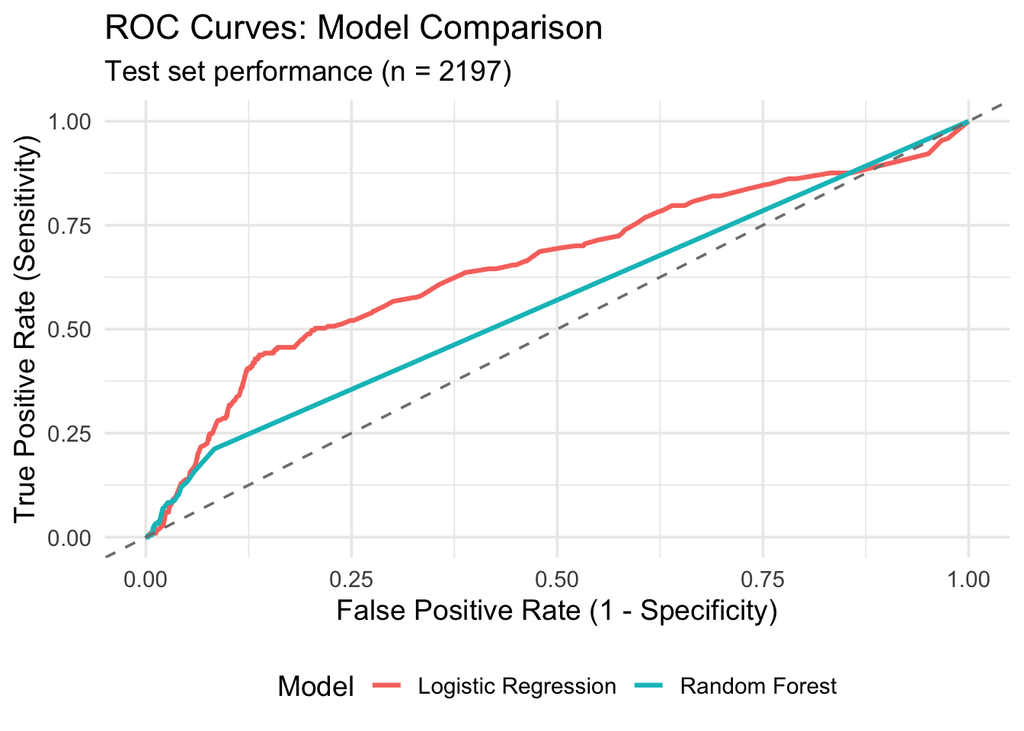

```r
library(pROC)
library(ggplot2)
library(dplyr)

# Create test-set predicted probabilities (so objects exist during render)
lr_test_probs <- predict(lr_fit, new_data = test, type = "prob") %>%
  bind_cols(truth = test$stage_advanced)

rf_test_probs <- predict(rf_fit, new_data = test, type = "prob") %>%
  bind_cols(truth = test$stage_advanced)

# ROC curves
lr_roc <- roc(lr_test_probs$truth, lr_test_probs$.pred_late)
rf_roc <- roc(rf_test_probs$truth, rf_test_probs$.pred_late)
roc_data <- bind_rows(
  tibble(fpr = 1 - lr_roc$specificities, tpr = lr_roc$sensitivities, model = "Logistic Regression"),
  tibble(fpr = 1 - rf_roc$specificities, tpr = rf_roc$sensitivities, model = "Random Forest")
)

ggplot(roc_data, aes(x = fpr, y = tpr, color = model)) +
  geom_line(linewidth = 1.1) +
  geom_abline(linetype = "dashed", color = "gray50") +
  labs(
    title = "ROC Curves: Model Comparison",
    subtitle = paste0("Test set performance (n = ", nrow(test), ")"),
    x = "False Positive Rate (1 - Specificity)",
    y = "True Positive Rate (Sensitivity)",
    color = "Model"
  ) +
  theme_minimal(base_size = 14) +
  theme(legend.position = "bottom")
```

## 4.9 Addressing Class Imbalance

### 4.9.1 Downsampling inside resampling

```r
# starts from original base recipe and adds downsampling.  During the model training inside each CV fold it randomly downsamples early-stage so its balanced with late stage
rec_down <- base_recipe %>%
  step_downsample(stage_advanced)

# Create new workflows that use the downsampling recipe - every training fold is balanced before fitting.
lr_wf_down <- workflow() %>%
  add_model(lr_spec) %>%
  add_recipe(rec_down)

rf_wf_down <- workflow() %>%
  add_model(rf_spec) %>%
  add_recipe(rec_down)

# Run 10-fold CV again, but now with downsampling - apply the recipe to the 90% training subset, fit the model on the downsampled training data, then evaluate predictions on the original 10% validation fold (not downsampled)
lr_cv_down <- fit_resamples(lr_wf_down, folds, control = ctrl)
```

[output not shown]

[output not shown]

[output not shown]

[output not shown]

```r
rf_cv_down <- fit_resamples(rf_wf_down, folds, control = ctrl)
```

[output not shown]

[output not shown]

[output not shown]

[output not shown]

```r
# Collect and compare AUCs with downsampling
bind_rows(
  collect_metrics(lr_cv_down) %>%
    filter(.metric == "roc_auc") %>%
    mutate(Model = "LR (CV, downsample)"),
  collect_metrics(rf_cv_down) %>%
    filter(.metric == "roc_auc") %>%
    mutate(Model = "RF (CV, downsample)")
) %>%
  dplyr::select(Model, mean, std_err) %>%
  gt() %>%
  tab_header(title = "AUC with downsampling (10-fold CV)")
```

AUC with downsampling (10-fold CV)

| Model | mean | std_err |
| --- | --- | --- |
| LR (CV, downsample) | 0.6509376 | 0.009792485 |
| RF (CV, downsample) | 0.6504210 | 0.008990845 |

After incorporating downsampling within resampling, both logistic regression and random forest achieved similar cross-validated AUCs (~0.65), suggesting that addressing class imbalance improved model fairness toward late-stage cases. The comparable results indicate that both models are capturing a similar level of signal, though overall discrimination is still moderate.

## 4.10 Test-set performance with downsampled models

```r
# Fit downsampled workflows on the full 80% training set
lr_fit_down <- fit(lr_wf_down, train)
rf_fit_down <- fit(rf_wf_down, train)
# Predict on the same 20% test set (NOT downsampled)
lr_test_probs_down <- predict(lr_fit_down, test, type = "prob") %>%
  bind_cols(truth = test$stage_advanced)

rf_test_probs_down <- predict(rf_fit_down, test, type = "prob") %>%
  bind_cols(truth = test$stage_advanced)

# Compute AUC on the test set for each downsampled model
lr_auc_test_down <- roc_auc(lr_test_probs_down, truth, .pred_late, event_level = "second")
rf_auc_test_down <- roc_auc(rf_test_probs_down, truth, .pred_late, event_level = "second")

# Compare unweighted vs downsampled in one table
bind_rows(
  tibble(Model = "LR (Test, unweighted)",   AUC = lr_auc_test$.estimate),
  tibble(Model = "RF (Test, unweighted)",   AUC = rf_auc_test$.estimate),
  tibble(Model = "LR (Test, downsampled)",  AUC = lr_auc_test_down$.estimate),
  tibble(Model = "RF (Test, downsampled)",  AUC = rf_auc_test_down$.estimate)
) %>%
  gt() %>%
  tab_header(title = "Test set AUCs: Unweighted vs Downsampled")
```

Test set AUCs: Unweighted vs Downsampled

| Model | AUC |
| --- | --- |
| LR (Test, unweighted) | 0.6530384 |
| RF (Test, unweighted) | 0.5646430 |
| LR (Test, downsampled) | 0.6573256 |
| RF (Test, downsampled) | 0.6628928 |

Downsampling produced only a small improvement in the logistic regression model because logistic regression is a stable, linear model that already handles class imbalance relatively well, especially with ridge regularization.This may be why there was a small change in AUC (0.65 → 0.66).

# 5 Model Interpretation

```r
# Model Interpretation (downsampled models)

library(broom)
library(gt)
library(vip)

# Logistic regression coefficients from the *downsampled* model
lr_coefs <- tidy(lr_fit_down) %>%
  filter(term != "(Intercept)") %>%
  arrange(desc(abs(estimate)))
lr_coefs %>%
  gt() %>%
  tab_header(title = "Logistic regression coefficients (downsampled, penalized glmnet)")
```

Logistic regression coefficients (downsampled, penalized glmnet)

| term | estimate | penalty |
| --- | --- | --- |
| resfnl_c3_X0 | 0.3421587551 | 0.1 |
| resfnl_c3_X1 | -0.3418693281 | 0.1 |
| riskBCSC_v2_5y_cat_X..4.00 | 0.2985967753 | 0.1 |
| examyear_cat_X2005.2008 | -0.1529344798 | 0.1 |
| resinit_c_X0 | 0.1516901103 | 0.1 |
| resinit_c_X1 | -0.1514305329 | 0.1 |
| riskBCSC_v2_5y_cat_X0.00.to...1.00 | 0.1415483636 | 0.1 |
| age_group2young_x_density_binarynot_dense | -0.1399612970 | 0.1 |
| riskBCSC_v2_5y_cat_X2.50.to.3.99 | -0.1382281662 | 0.1 |
| examyear_cat_X2015.2017 | 0.1327191088 | 0.1 |
| density_binary_dense | 0.1323245506 | 0.1 |
| density_binary_not_dense | -0.1322768548 | 0.1 |
| resfnl_c_X1 | -0.0900453114 | 0.1 |
| resfnl_c_X0 | 0.0892805934 | 0.1 |
| riskBCSC_v2_5y_cat_X1.00.to.1.66 | -0.0753216497 | 0.1 |
| riskBCSC_v2_5y_cat_X1.67.to.2.49 | 0.0442853742 | 0.1 |
| examyear_cat_X2009.2010 | -0.0282612855 | 0.1 |
| examyear_cat_X2011.2012 | 0.0270968257 | 0.1 |
| age_group2_older | -0.0212343594 | 0.1 |
| age_group2_young | 0.0212203723 | 0.1 |
| examyear_cat_X2013.2014 | -0.0005510343 | 0.1 |

```r
library(dplyr)
library(ggplot2)

# Attach truth column to prediction probabilities
conf_mat_data <- bind_cols(
  test %>% dplyr::select(stage_advanced),   # truth from test
  lr_test_probs_down                        # predicted probs (.pred_late)
) %>%
  mutate(
    predicted      = if_else(.pred_late > 0.5, "late", "early"),
    stage_advanced = factor(stage_advanced, levels = c("early", "late")),
    predicted      = factor(predicted,      levels = c("early", "late"))
  )

# make confusion table as counts
conf_df <- conf_mat_data %>%
  count(stage_advanced, predicted, name = "Freq") %>%
  rename(
    truth      = stage_advanced,
    prediction = predicted
  )

conf_df
```

```
# A tibble: 4 × 3
  truth prediction  Freq
  <fct> <fct>      <int>
1 early early       1629
2 early late         351
3 late  early        116
4 late  late         101
```

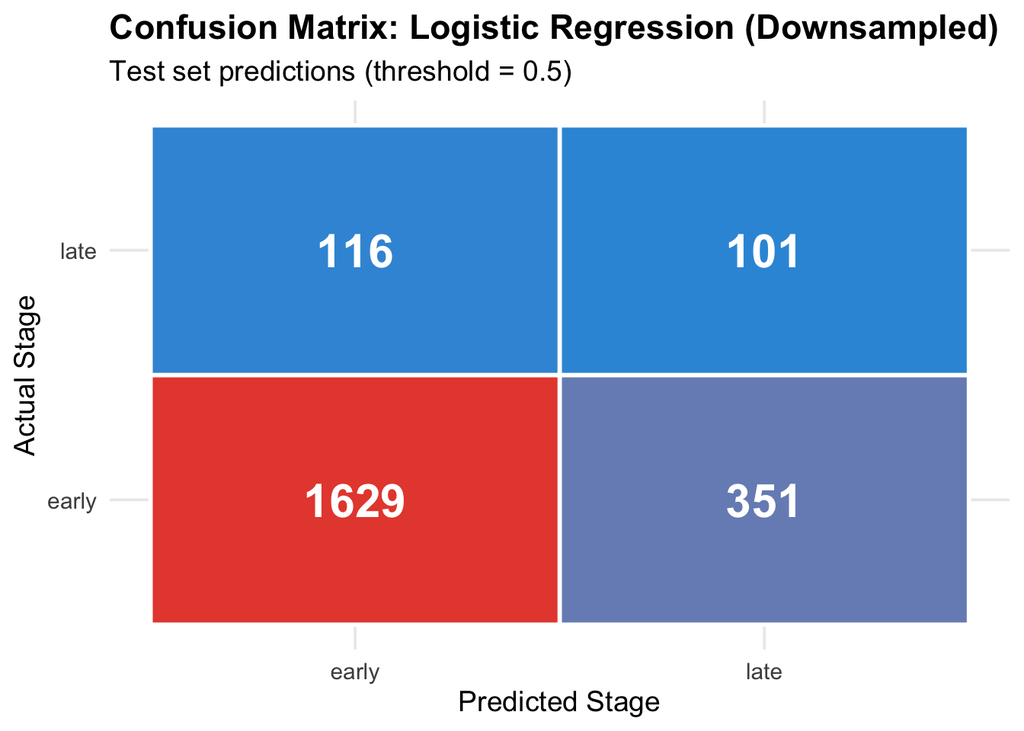

```r
# Plot confusion matrix
ggplot(conf_df, aes(x = prediction, y = truth, fill = Freq)) +
  geom_tile(color = "white", size = 1) +
  geom_text(aes(label = Freq), size = 8, color = "white", fontface = "bold") +
  scale_fill_gradient(low = "#3498DB", high = "#E74C3C") +
  labs(
    title    = "Confusion Matrix: Logistic Regression (Downsampled)",
    subtitle = "Test set predictions (threshold = 0.5)",
    x        = "Predicted Stage",
    y        = "Actual Stage"
  ) +
  theme_minimal(base_size = 14) +
  theme(
    plot.title      = element_text(face = "bold"),
    legend.position = "none"
  )
```

Using a 0.5 threshold, the downsampled logistic regression model correctly identified 101 late-stage cancers, but misclassified 116 as early stage, indicating low sensitivity for detecting late disease. For early-stage cancers, the model correctly classified 1,629 cases, misclassifying 351 as late stage. Overall, the model shows strong ability to recognize early-stage cancers (high specificity) but limited accuracy in detecting late-stage cancers.

```r
# RF importance with intuitive names

library(dplyr)
library(gt)
library(vip)
library(ggplot2)

# table with intuitive labels
rf_imp_clean <- vi(rf_fit_down) %>%
  mutate(Variable_pretty = case_when(
    grepl("^resfnl_c3_", Variable)              ~ "Final BI-RADS (Category 3)",
    grepl("^resfnl_c_", Variable)               ~ "Final BI-RADS",
    grepl("^resinit_c_", Variable)              ~ "Initial BI-RADS",
    grepl("^age_group2_", Variable)             ~ "Age Group",
    grepl("^density_binary_", Variable)         ~ "Breast Density (Dense vs Non-dense)",
    grepl("^riskBCSC_v2_5y_cat", Variable)      ~ "BCSC 5-Year Risk Category",
    TRUE                                        ~ Variable
  )) %>%
  arrange(desc(Importance))

# gt table
rf_imp_clean %>%
  dplyr::select(Variable = Variable_pretty, Importance) %>%
  gt() %>%
  tab_header(title = "Random Forest Variable Importance (Downsampled Model)")
```

Random Forest Variable Importance (Downsampled Model)

| Variable | Importance |
| --- | --- |
| Final BI-RADS (Category 3) | 17.6641702 |
| Final BI-RADS (Category 3) | 16.4393402 |
| Initial BI-RADS | 10.2223833 |
| Initial BI-RADS | 8.7920473 |
| Final BI-RADS | 8.2065509 |
| Final BI-RADS | 6.0856730 |
| Breast Density (Dense vs Non-dense) | 6.0747520 |
| Breast Density (Dense vs Non-dense) | 5.8283426 |
| BCSC 5-Year Risk Category | 4.2489432 |
| BCSC 5-Year Risk Category | 4.0784591 |
| examyear_cat_X2015.2017 | 4.0150551 |
| BCSC 5-Year Risk Category | 3.6621310 |
| Age Group | 3.3438366 |
| Age Group | 1.7667505 |
| age_group2young_x_density_binarynot_dense | 1.7324607 |
| BCSC 5-Year Risk Category | 1.2128192 |
| examyear_cat_X2009.2010 | -0.6741892 |
| BCSC 5-Year Risk Category | -1.0429578 |
| examyear_cat_X2011.2012 | -1.8083850 |
| examyear_cat_X2013.2014 | -2.1929792 |
| examyear_cat_X2005.2008 | -2.9144806 |

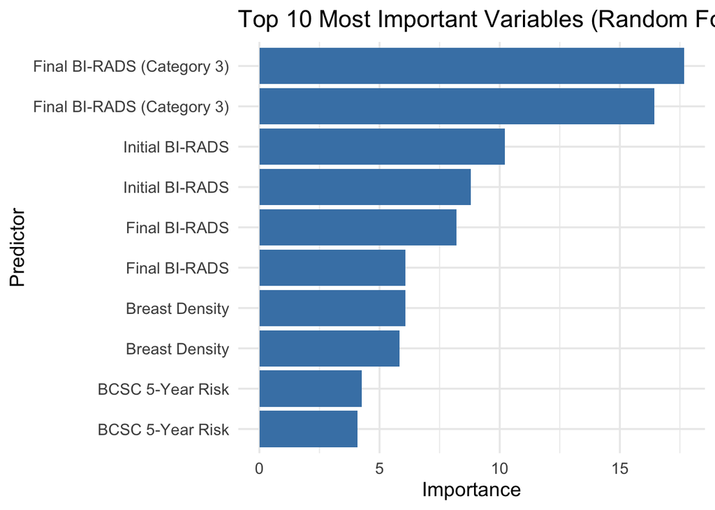

```r
# VIP plot with intuitive labels
vip(rf_fit_down, num_features = 10, aesthetics = list(fill = "steelblue")) +
  scale_x_discrete(labels = function(x) dplyr::case_when(
    grepl("^resfnl_c3_", x)              ~ "Final BI-RADS (Category 3)",
    grepl("^resfnl_c_", x)               ~ "Final BI-RADS",
    grepl("^resinit_c_", x)              ~ "Initial BI-RADS",
    grepl("^age_group2_", x)             ~ "Age Group",
    grepl("^density_binary_", x)         ~ "Breast Density",
    grepl("^riskBCSC_v2_5y_cat", x)      ~ "BCSC 5-Year Risk",
    TRUE                                 ~ x
  )) +
  labs(
    x = "Predictor",
    y = "Importance",
    title = "Top 10 Most Important Variables (Random Forest, Downsampled)"
  ) +
  theme_minimal(base_size = 14)
```

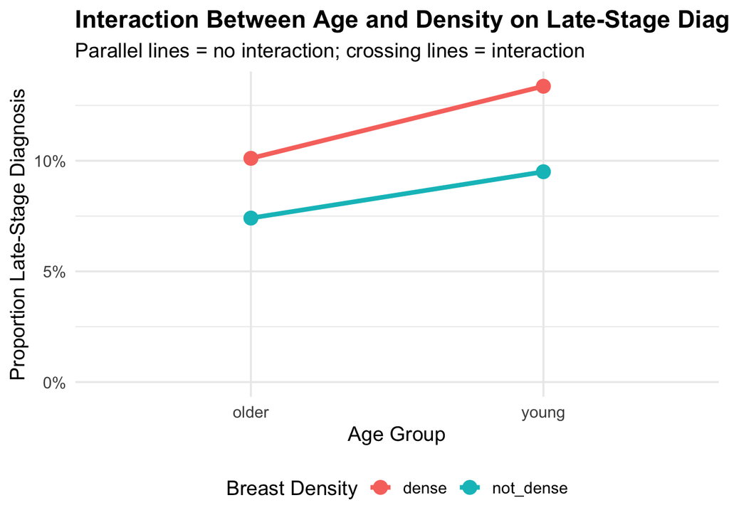

```r
library(ggplot2)

# Calculate proportions for interaction plot
interaction_data <- mmg_clean %>%
  group_by(age_group2, density_binary, stage_advanced) %>%
  summarise(n = n(), .groups = "drop") %>%
  group_by(age_group2, density_binary) %>%
  mutate(prop = n / sum(n)) %>%
  filter(stage_advanced == "late")

# Interaction plot
ggplot(interaction_data, aes(x = age_group2, y = prop,
                             color = density_binary, group = density_binary)) +
  geom_line(size = 1.5) +
  geom_point(size = 4) +
  scale_y_continuous(labels = scales::percent_format(),
                     limits = c(0, NA)) +
  labs(
    title = "Interaction Between Age and Density on Late-Stage Diagnosis",
    subtitle = "Parallel lines = no interaction; crossing lines = interaction",
    x = "Age Group",
    y = "Proportion Late-Stage Diagnosis",
    color = "Breast Density"
  ) +
  theme_minimal(base_size = 14) +
  theme(
    plot.title = element_text(face = "bold"),
    legend.position = "bottom"
  )
```

Because the lines are nearly parallel, breast density has a similar impact on late-stage diagnosis across age groups, indicating no meaningful interaction between age and density.

## 5.2 References

Boyd, N. F., Guo, H., Martin, L. J., Sun, L., Stone, J., Fishell, E., Jong, R. A., Hislop, G., Chiarelli, A., Minkin, S., & Yaffe, M. J. (2007). Mammographic density and the risk and detection of breast cancer. *New England Journal of Medicine*, 356(3), 227–236. https://doi.org/10.1056/NEJMoa062790

Checka, C. M., Chun, J. E., Schnabel, F. R., Lee, J., & Toth, H. (2012). The relationship of mammographic density and age: Implications for breast cancer screening. *American Journal of Roentgenology*, 198(3), W292–W295. https://doi.org/10.2214/AJR.10.6049

Kerlikowske, K., Zhu, W., Tosteson, A. N. A., Sprague, B. L., Tice, J. A., Lehman, C. D., Miglioretti, D. L., & Breast Cancer Surveillance Consortium. (2015). Identifying women with dense breasts at high risk for interval cancer: A cohort study. *Annals of Internal Medicine*, 162(10), 673–681. https://doi.org/10.7326/M14-1465

Niraula, S., Ocana, A., Ennis, M., & Goodwin, P. J. (2020). Breast cancer diagnosis and survival among women with interval breast cancers. *JAMA Network Open*, 3(12), e2028214. https://doi.org/10.1001/jamanetworkopen.2020.28214

Siegel, R. L., Miller, K. D., Wagle, N. S., & Jemal, A. (2023). Cancer statistics, 2023. *CA: A Cancer Journal for Clinicians*, 73(1), 17–48. https://doi.org/10.3322/caac.21763

Zhu, Y., Zhang, J., Liu, Q., & Li, X. (2023). Breast cancer in young women: Biological characteristics and clinical outcomes. *Cancers*, 15(6), 1917. https://doi.org/10.3390/cancers15061917